# Functions, for loops etc.

Sabrina McNew

2023-11-28

```r
library(palmerpenguins)
library(dplyr)
```

### Functions

You can create a function in R instead of copying code many times over. Common applications:

- Plots
- Wrangling / Processing
- Convenience functions (e.g., standard error)

Anatomy of a function:  
(Modify things in italics with your own information)  
*name.of.function* <- function( *arguments =* ) {  
*things function does*  
}

### Some toy functions

```r
affirmation <- function (name){
  paste(name, "is awesome", sep = " ")
}
affirmation(name = "margaret")
```

```
## [1] "margaret is awesome"
```

```r
class_list <- c("margaret", "isabella", "maddie")
affirmation(class_list)
```

```
## [1] "margaret is awesome" "isabella is awesome" "maddie is awesome"
```

Another example: R does not have a native standard error function. We could download a package (plotrix) and use its std.error() function or we could make our own.

```r
# Note: your arguments can be called whatever you want, it's just a placeholder

standard.error <- function(blue){
  sd(blue)/sqrt(length(blue))
}
standard.error(1:10)
```

```
## [1] 0.9574271
```

```r
#let's double check this gives us the same answer as plotrix's function
plotrix::std.error(1:10)
```

```
## [1] 0.9574271
```

```r
# We can also make functions with multiple arguments
fun = function(x,y){
  x*y
}
fun(y = 1:5, x = c(100,200,300,400,500))
```

```
## [1]  100  400  900 1600 2500
```

#### Pros and Cons of DIY Functions:

Pros:

- Customizable
- Lowers chances that you’ll mess up copying and pasting code
- Shortens/condenses code

Cons

- Possible to create a function that has unexpected or undesired behavior, and to not notice it because you are just using it blindly
- Very good idea to “sanity check” your DIY functions against either a built-in function or some set of representative tests.

### For Loops

A for loop is a programming convention that allows us to do something many times. In R, we don’t have to use for loops as often as some other languages, because R is vectorized, and often will just apply the function to each item in the vector (see examples above). However, there are plenty of opportunities to use loops.

An example: Say we want to simulate t-tests comparing two populations that are either a priori different or the same. We can simulate these data by asking R to draw samples from a normal distribution with rnorm()

```r
# x and y are populations with the same mean (5)
# Will the t.test correctly tell us that there's no difference in means?
x <- rnorm(n = 100, mean = 5, sd = 1)
y <- rnorm(n = 100, mean = 5, sd = 1)
t.test(x, y)$p.value
```

```
## [1] 0.9072768
```

```r
# usually it does, but every once in a while by chance we'll get a
# significant result (aka a type I error)

x <- rnorm(n = 100, mean = 5, sd = 1)
y <- rnorm(n = 100, mean = 5, sd = 1)
t.test(x, y)$p.value
```

```
## [1] 0.2367206
```

```r
x <- rnorm(n = 100, mean = 5, sd = 1)
y <- rnorm(n = 100, mean = 5, sd = 1)
t.test(x, y)$p.value
```

```
## [1] 0.2155788
```

We could copy and paste this code and/or run it a bunch of times but that gets kind of tedious. Let’s put it into a loop instead.

The structure of a loop is similar to a function:  
*for (i in vector) {do something involving i }*  
means that for every value in the vector, we will do whatever is in the bracket, substituting “i” for whatever value of the vector we’re on. It’s common to iterate over numeric vectors like for (i in 1:100). In that case, the first i is 1, the second i is 2, and so on. For each iteration of the loop, it will replace i with 1, 2, 3, etc. until it gets to the last value in the vector.

```r
# Start by creating a placeholder vector to save our looped results
# Remember we can index vectors using []. vector[1] returns the
# first item in the vector, vector[20] returns the 20th item.

myps <- rep(NA, 1000)

# Make a loop.
# Save the p value in the ith spot of myps vector
for (i in 1:1000) {
  x <- rnorm(n = 100, mean = 5, sd = 1)
  y <- rnorm(n = 100, mean = 5, sd = 1)
myps[i] <- t.test(x, y)$p.value
}
# What does our myps vector look like now?
head(myps)
```

```
## [1] 0.14757429 0.89379367 0.20717639 0.01593672 0.96145027 0.38541773
```

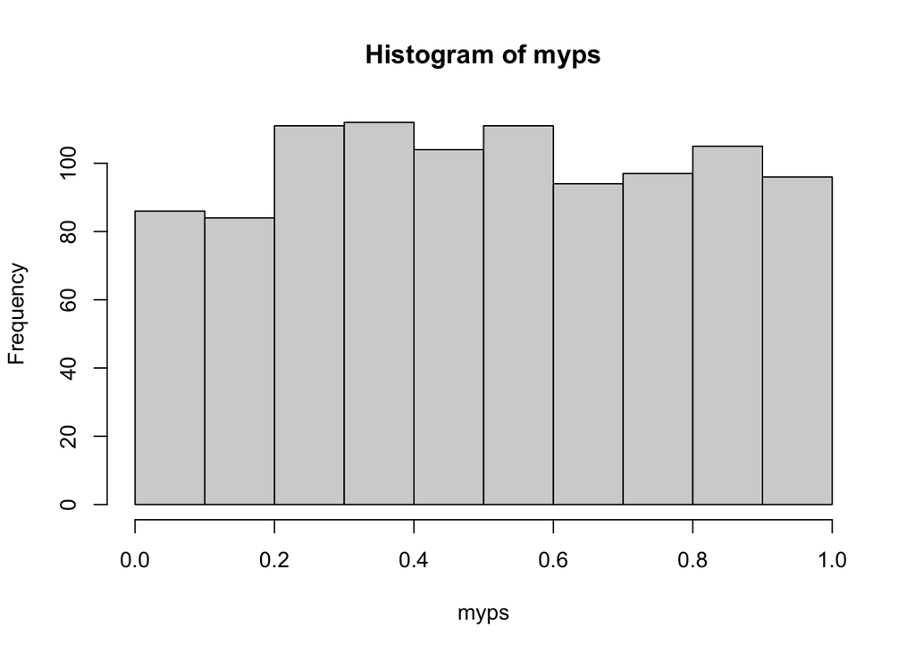

```r
# What's the distribution of our p values? Under a no-difference
# scenario, the ps should be uniformly distributed
hist(myps)
```

```r
# How many ps were false positives? I.e. < 0.05?, should be approx 5% of 1000
myps[myps < 0.05] %>% length()
```

```
## [1] 47
```

We can also combine for loops and functions

```r
# Create a function that simulates a t test between
# samples drawn from populations with known means
simulated.t.test <- function(meanx, meany) {
x <- rnorm(n = 100, mean = meanx, sd = 1)
y <- rnorm(n = 100, mean = meany, sd = 1)
t.test(x, y)$p.value
}

simulated.t.test(meanx = 5, meany = 5) # should be > 0.05
```

```
## [1] 0.1937746
```

```r
simulated.t.test(meanx = 5, meany = 8) # should be < 0.05
```

```
## [1] 8.298102e-53
```

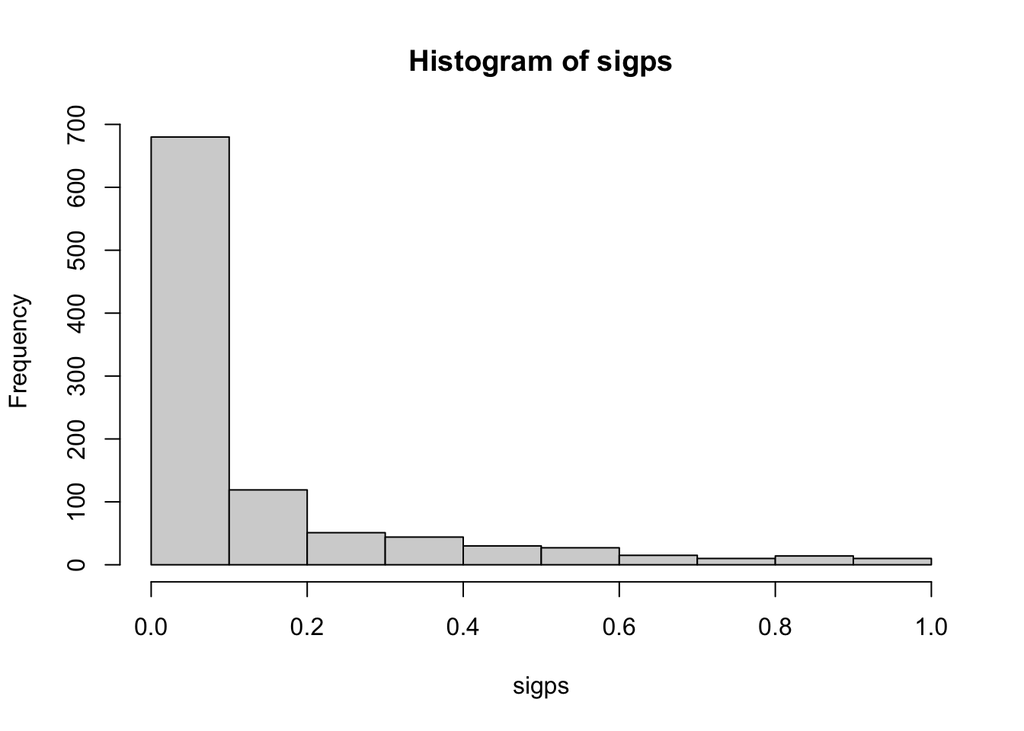

```r
# Throw the function into a loop. Let's see how often our t.test
# can detect a significant difference between populations that do differ
# slightly

sigps <- NULL # vector to save results
for (i in 1:1000){
  sigps[i] <- simulated.t.test(meanx = 5, meany = 5.3)
}

hist(sigps)
```

```r
# How many ps were significant? (This is akin to a power simulation), only
# ~50% of the time did we detect a true difference, so our power was 50%
sigps[sigps < 0.05] %>% length
```

```
## [1] 544
```

### Applys

There’s a big family of functions in R called apply- they’re not scary! They’re actually pretty similar to for loops.

- The basic apply() will perform functions on rows or columns of your choosing
- sapply() and lapply() work a lot like loops
- mapply() will apply function to multiple lists/vectors

```r
# apply example: what if we want to calculate standard
# deviation on all the columns in a dataframe?

# Create a clean toy dataframe with numeric columns from penguins
penguins_morph <- penguins %>%
  select(bill_length_mm, bill_depth_mm, flipper_length_mm, body_mass_g) %>%   na.omit() %>%
  as.data.frame()

# We could calculate sd for each column individually...
sd(penguins_morph$bill_length_mm)
```

```
## [1] 5.459584
```

```r
# Remember that dataframe[row,column] is a way to index dataframes in base r. So we can also grab the first column like this:
sd(penguins_morph[,1])
```

```
## [1] 5.459584
```

```r
# We could do it in a loop
# This says for 1:4 (the number of columns we have)
# Calculate the sd of the ith column and then print it
for (i in 1:4){
  sd(penguins_morph[,i]) %>% print()
}
```

```
## [1] 5.459584
## [1] 1.974793
## [1] 14.06171
## [1] 801.9545
```

```r
# we can do it in apply(), which will apply a function to either rows
# or columns in a dataframe.
# apply's arguments are:
# X = the data frame
# MARGIN = 1 (to apply the thing to each row) or 2 (to apply the thing to each column) FUN = function of interest)

apply(X = penguins_morph, MARGIN = 2, FUN = sd)
```

```
##    bill_length_mm     bill_depth_mm flipper_length_mm       body_mass_g
##          5.459584          1.974793         14.061714        801.954536
```

More flexible than apply() are sapply() and lapply() which apply FUN to each value of X (a vector, list etc.). Notice you can put any function into the FUN argument, and if you create your own you don’t put the {} in there.

```r
sapply(X = 1:4, FUN = function (x) sd(penguins_morph[,x])) # returns a vector
```

```
## [1]   5.459584   1.974793  14.061714 801.954536
```

```r
lapply(X = 1:4, FUN = function (x) sd(penguins_morph[,x])) # returns a list
```

```
## [[1]]
## [1] 5.459584
##
## [[2]]
## [1] 1.974793
##
## [[3]]
## [1] 14.06171
##
## [[4]]
## [1] 801.9545
```

### Finally, a little exercise:

A data processing scenario: You have done some lab work which produces values of interest for each well on a plate. However, you need to connect the values that came out of the microplate reader to your “metadata” i.e. sample and well info.

```r
# Some path corrections are required while working in markdown
# If these don't work for you check your path using getwd() and adjust
# accordingly.

plate1 <- read.csv("../datasets/results/plate1.csv")
plate2 <- read.csv("../datasets/results/plate2.csv")
plate3 <- read.csv("../datasets/results/plate3.csv")
metadata <- read.csv("../datasets/results/metadata.csv")
head(metadata)
```

```
##    plate well sample treatment
## 1 plate1   A1      1         a
## 2 plate1   A2      2         a
## 3 plate1   A3      3         a
## 4 plate1   A4      4         a
## 5 plate1   A5      5         a
## 6 plate1   A6      6         b
```

```r
head(plate1)
```

```
##   well     value
## 1   A1 0.9322915
## 2   A2 0.0162497
## 3   A3 0.8390444
## 4   A4 0.4079772
## 5   A5 0.2239907
## 6   A6 0.4385581
```

### Your task:

- Figure out how to join the sample and treatment columns onto plate 1
- Note that the wells (A1…) repeat on each plate… how do you come up with a unique identifyer?
- Figure out how to turn this procedure into a function so it could be used to process any plate that you run
- Loop this function to process all 3 plates.